# Section #1: Assembly quality after host removal

### Visualisation of quast output

> **Input:** Comparison between Assembly metrics using QUAST report
> 1. Between Bowtie2-filtered contigs and Original metagenome
> 2. Between Original metagenome, contaminated metagenome, EukRep, Kraken2 and Tiara

```python
import pandas as pd
import numpy as np
import matplotlib.pyplot as plt
import numpy as np
import matplotlib.pyplot as plt
import pandas as pd
from pathlib import Path
import matplotlib.ticker as mticker
```

```python
df_quast = pd.read_csv("report.tsv", sep="\t")
```

```python
df_quast.head()
pd.set_option('display.float_format', '{:.0f}'.format)
display(df_quast)
df_quast = pd.read_csv("report.tsv", sep="\t")
# Only Bowtie2 comparison to original_metagenome
df_bowtie2 = df_quast.drop(columns=["contaminated_metagenome", "eukrep", "kraken2", "tiara"], errors="ignore")
display(df_bowtie2)
```

|  | Assembly | bowtie2 | original_metagenome | contaminated_metagenome | eukrep | kraken2 | tiara |
| --- | --- | --- | --- | --- | --- | --- | --- |
| 0 | # contigs (>= 0 bp) | 16900 | 16910 | 16853 | 16744 | 16849 | 16739 |
| 1 | # contigs (>= 1000 bp) | 16900 | 16910 | 16853 | 16744 | 16849 | 16739 |
| 2 | # contigs (>= 5000 bp) | 3725 | 3727 | 3754 | 3715 | 3752 | 3751 |
| 3 | # contigs (>= 10000 bp) | 2137 | 2137 | 2159 | 2146 | 2157 | 2159 |
| 4 | # contigs (>= 25000 bp) | 1012 | 1011 | 1022 | 1022 | 1020 | 1022 |
| 5 | # contigs (>= 50000 bp) | 475 | 478 | 474 | 474 | 473 | 474 |
| 6 | Total length (>= 0 bp) | 126901823 | 126900859 | 126269061 | 125666298 | 126180578 | 126006716 |
| 7 | Total length (>= 1000 bp) | 126901823 | 126900859 | 126269061 | 125666298 | 126180578 | 126006716 |
| 8 | Total length (>= 5000 bp) | 95076877 | 95060215 | 94671488 | 94324869 | 94588497 | 94651608 |
| 9 | Total length (>= 10000 bp) | 84215119 | 84170386 | 83728356 | 83569825 | 83645365 | 83728356 |
| 10 | Total length (>= 25000 bp) | 66452882 | 66429388 | 65793603 | 65793603 | 65710612 | 65793603 |
| 11 | Total length (>= 50000 bp) | 47454934 | 47562596 | 46475780 | 46475780 | 46422675 | 46475780 |
| 12 | # contigs | 16900 | 16910 | 16853 | 16744 | 16849 | 16739 |
| 13 | Largest contig | 846797 | 846787 | 802028 | 802028 | 802028 | 802028 |
| 14 | Total length | 126901823 | 126900859 | 126269061 | 125666298 | 126180578 | 126006716 |
| 15 | GC (%) | 46 | 46 | 46 | 46 | 46 | 46 |
| 16 | N50 | 28605 | 28568 | 27954 | 28397 | 27920 | 28057 |
| 17 | N90 | 2204 | 2204 | 2199 | 2194 | 2198 | 2206 |
| 18 | auN | 65351 | 64937 | 61718 | 61979 | 61731 | 61840 |
| 19 | L50 | 900 | 900 | 922 | 911 | 921 | 917 |
| 20 | L90 | 9845 | 9852 | 9820 | 9738 | 9820 | 9734 |
| 21 | # N's per 100 kbp | 0 | 0 | 0 | 0 | 0 | 0 |

|  | Assembly | bowtie2 | original_metagenome |
| --- | --- | --- | --- |
| 0 | # contigs (>= 0 bp) | 16900 | 16910 |
| 1 | # contigs (>= 1000 bp) | 16900 | 16910 |
| 2 | # contigs (>= 5000 bp) | 3725 | 3727 |
| 3 | # contigs (>= 10000 bp) | 2137 | 2137 |
| 4 | # contigs (>= 25000 bp) | 1012 | 1011 |
| 5 | # contigs (>= 50000 bp) | 475 | 478 |
| 6 | Total length (>= 0 bp) | 126901823 | 126900859 |
| 7 | Total length (>= 1000 bp) | 126901823 | 126900859 |
| 8 | Total length (>= 5000 bp) | 95076877 | 95060215 |
| 9 | Total length (>= 10000 bp) | 84215119 | 84170386 |
| 10 | Total length (>= 25000 bp) | 66452882 | 66429388 |
| 11 | Total length (>= 50000 bp) | 47454934 | 47562596 |
| 12 | # contigs | 16900 | 16910 |
| 13 | Largest contig | 846797 | 846787 |
| 14 | Total length | 126901823 | 126900859 |
| 15 | GC (%) | 46 | 46 |
| 16 | N50 | 28605 | 28568 |
| 17 | N90 | 2204 | 2204 |
| 18 | auN | 65351 | 64937 |
| 19 | L50 | 900 | 900 |
| 20 | L90 | 9845 | 9852 |
| 21 | # N's per 100 kbp | 0 | 0 |

#### Comparing QUAST output for datasets and tools except Bowtie2

```python
df_final = pd.read_csv("report.tsv", sep="\t")
# Drop bowtie2 (if present)
df_final = df_final.drop(columns=["bowtie2"], errors="ignore")

# Reorder columns (keep only those that actually exist)
order = ["Assembly", "original_metagenome", "contaminated_metagenome", "eukrep", "kraken2", "tiara"]
df_final = df_final[[c for c in order if c in df_final.columns]]

display(df_final)
```

|  | Assembly | original_metagenome | contaminated_metagenome | eukrep | kraken2 | tiara |
| --- | --- | --- | --- | --- | --- | --- |
| 0 | # contigs (>= 0 bp) | 16910 | 16853 | 16744 | 16849 | 16739 |
| 1 | # contigs (>= 1000 bp) | 16910 | 16853 | 16744 | 16849 | 16739 |
| 2 | # contigs (>= 5000 bp) | 3727 | 3754 | 3715 | 3752 | 3751 |
| 3 | # contigs (>= 10000 bp) | 2137 | 2159 | 2146 | 2157 | 2159 |
| 4 | # contigs (>= 25000 bp) | 1011 | 1022 | 1022 | 1020 | 1022 |
| 5 | # contigs (>= 50000 bp) | 478 | 474 | 474 | 473 | 474 |
| 6 | Total length (>= 0 bp) | 126900859 | 126269061 | 125666298 | 126180578 | 126006716 |
| 7 | Total length (>= 1000 bp) | 126900859 | 126269061 | 125666298 | 126180578 | 126006716 |
| 8 | Total length (>= 5000 bp) | 95060215 | 94671488 | 94324869 | 94588497 | 94651608 |
| 9 | Total length (>= 10000 bp) | 84170386 | 83728356 | 83569825 | 83645365 | 83728356 |
| 10 | Total length (>= 25000 bp) | 66429388 | 65793603 | 65793603 | 65710612 | 65793603 |
| 11 | Total length (>= 50000 bp) | 47562596 | 46475780 | 46475780 | 46422675 | 46475780 |
| 12 | # contigs | 16910 | 16853 | 16744 | 16849 | 16739 |
| 13 | Largest contig | 846787 | 802028 | 802028 | 802028 | 802028 |
| 14 | Total length | 126900859 | 126269061 | 125666298 | 126180578 | 126006716 |
| 15 | GC (%) | 46 | 46 | 46 | 46 | 46 |
| 16 | N50 | 28568 | 27954 | 28397 | 27920 | 28057 |
| 17 | N90 | 2204 | 2199 | 2194 | 2198 | 2206 |
| 18 | auN | 64937 | 61718 | 61979 | 61731 | 61840 |
| 19 | L50 | 900 | 922 | 911 | 921 | 917 |
| 20 | L90 | 9852 | 9820 | 9738 | 9820 | 9734 |
| 21 | # N's per 100 kbp | 0 | 0 | 0 | 0 | 0 |

#### Keeping metrics of interest

```python
metric_col = df_final.columns[0]
rows_to_keep = [
    "# contigs (>= 0 bp)",
    "# contigs (>= 10000 bp)",
    "# contigs (>= 50000 bp)",
    "Total length (>= 0 bp)",
    "Total length (>= 10000 bp)",
    "Total length (>= 50000 bp)",
    "Largest contig",
    "N50",
    "L50",
]
mask = df_final[metric_col].isin(rows_to_keep)
df_keep = df_final[mask].copy()
df_keep[metric_col] = pd.Categorical(df_keep[metric_col], rows_to_keep, ordered=True)
df_keep = df_keep.sort_values(metric_col)
display(df_keep)
# save if needed
df_keep.to_csv("quast_filtered.tsv", sep="\t", index=False)
```

|  | Assembly | original_metagenome | contaminated_metagenome | eukrep | kraken2 | tiara |
| --- | --- | --- | --- | --- | --- | --- |
| 0 | # contigs (>= 0 bp) | 16910 | 16853 | 16744 | 16849 | 16739 |
| 3 | # contigs (>= 10000 bp) | 2137 | 2159 | 2146 | 2157 | 2159 |
| 5 | # contigs (>= 50000 bp) | 478 | 474 | 474 | 473 | 474 |
| 6 | Total length (>= 0 bp) | 126900859 | 126269061 | 125666298 | 126180578 | 126006716 |
| 9 | Total length (>= 10000 bp) | 84170386 | 83728356 | 83569825 | 83645365 | 83728356 |
| 11 | Total length (>= 50000 bp) | 47562596 | 46475780 | 46475780 | 46422675 | 46475780 |
| 13 | Largest contig | 846787 | 802028 | 802028 | 802028 | 802028 |
| 16 | N50 | 28568 | 27954 | 28397 | 27920 | 28057 |
| 19 | L50 | 900 | 922 | 911 | 921 | 917 |

# Section #2: Contig-level evaluation

> **Inputs:** a table with columns  
> `contig_id, length, aligned_bases, percent_aligned, eukrep, tiara, kraken2, ground_truth`  
> where tool columns and `ground_truth` are booleans (or mappable to True/False).

> **Outputs:**
> - Confusion matrices per tool (TP/TN/FP/FN)
> - Metrics per tool: Precision, Recall, Specificity
> - Optional: metrics vs contig-length bins (balanced bins)
> - Base-adjusted metrics (weighted by contig length in bp)

## 0) Load data

- Put your CSV/TSV in a path you control and set `INPUT_PATH` below.
- Columns required: `contig_id, length, aligned_bases, percent_aligned, eukrep, tiara, kraken2, ground_truth`.

```python
# replace with your table
df = pd.read_csv('85gt_contig.tsv', sep='\t')
```

## 1) Sanity checks & normalization

**Checklist:**

- Ensure tool columns and `ground_truth` are booleans (not `'true'/'false'` or `'-'`).
- Remove or impute ambiguous entries (e.g., `'-'`).
- Confirm `length` is numeric and ≥ 1,500 bp (or your chosen cutoff).

```python
#Drop rows with 'ambiguous'
df = df[~(df['ground_truth']=='ambiguous')]
```

```python
df.head()
```

|  | contig_id | length | aligned_bases | percent_aligned | eukrep | tiara | kraken2 | ground_truth |
| --- | --- | --- | --- | --- | --- | --- | --- | --- |
| 0 | k141_120550 | 1516 | 0 | 0 | False | False | False | False |
| 1 | k141_131508 | 1586 | 0 | 0 | False | False | False | False |
| 2 | k141_153427 | 1709 | 0 | 0 | False | False | False | False |
| 3 | k141_87672 | 3123 | 0 | 0 | False | False | False | False |
| 4 | k141_109595 | 1581 | 0 | 0 | False | False | False | False |

```python
df.tail()
```

|  | contig_id | length | aligned_bases | percent_aligned | eukrep | tiara | kraken2 | ground_truth |
| --- | --- | --- | --- | --- | --- | --- | --- | --- |
| 24579 | k141_76702 | 1669 | 0 | 0 | False | False | False | False |
| 24580 | k141_76703 | 22830 | 22716 | 100 | True | True | True | True |
| 24581 | k141_76704 | 20856 | 20854 | 100 | True | True | False | True |
| 24582 | k141_76708 | 7691 | 0 | 0 | False | False | False | False |
| 24583 | k141_76710 | 5960 | 5960 | 100 | False | True | False | True |

```python
for i in ['ground_truth', 'eukrep', 'tiara', 'kraken2']:
    print(i, df[i].value_counts())
```

```
ground_truth ground_truth
False    16853
True      7708
Name: count, dtype: int64
eukrep eukrep
False    18071
True      6490
Name: count, dtype: int64
tiara tiara
False    16835
True      7726
Name: count, dtype: int64
kraken2 kraken2
False    21443
True      3118
Name: count, dtype: int64
```

```python
tool_cols = ['eukrep', 'tiara', 'kraken2']
all_bool_cols = tool_cols + ['ground_truth']

def to_bool_series(s: pd.Series) -> pd.Series:
    s_norm = s.astype(str).str.strip().str.lower()
    mapped = s_norm.map({
        'true': True, 't': True, '1': True, 'yes': True, 'y': True,
        'false': False, 'f': False, '0': False, 'no': False, 'n': False
    })
    return mapped  # values not in the map become NaN

# Normalize boolean-like fields
for c in all_bool_cols:
    df[c] = to_bool_series(df[c])

df.head()
```

|  | contig_id | length | aligned_bases | percent_aligned | eukrep | tiara | kraken2 | ground_truth |
| --- | --- | --- | --- | --- | --- | --- | --- | --- |
| 0 | k141_120550 | 1516 | 0 | 0 | False | False | False | False |
| 1 | k141_131508 | 1586 | 0 | 0 | False | False | False | False |
| 2 | k141_153427 | 1709 | 0 | 0 | False | False | False | False |
| 3 | k141_87672 | 3123 | 0 | 0 | False | False | False | False |
| 4 | k141_109595 | 1581 | 0 | 0 | False | False | False | False |

```python
for i in ['ground_truth', 'eukrep', 'tiara', 'kraken2']:
    print(df[i].dtype)
```

```
bool
bool
bool
bool
```

## 2) Metrics & confusion matrix helpers

We compute **TP/TN/FP/FN** and the following metrics per tool:

- Precision = TP / (TP+FP) (Of all contigs the tool called “euk”, how many were actually euk?)
- Recall (Sensitivity) = TP / (TP+FN) (Of all true euks, how many did the tool find?)
- Specificity (TNR) = TN / (TN+FP) (Of all true non-euks, how many did the tool correctly reject?)

```python
pd.set_option('display.float_format', '{:.4f}'.format)
def confusion_counts(y_true: pd.Series, y_pred: pd.Series):
    TP = ((y_true == True) & (y_pred == True)).sum()
    TN = ((y_true == False) & (y_pred == False)).sum()
    FP = ((y_true == False) & (y_pred == True)).sum()
    FN = ((y_true == True) & (y_pred == False)).sum()
    return TP, TN, FP, FN

def _safe_div(num, den):
    return np.nan if den == 0 else (num / den)

def compute_metrics_df(subdf: pd.DataFrame, tool_col: str) -> pd.Series:
    y_true = subdf['ground_truth']
    y_pred = subdf[tool_col]

    TP, TN, FP, FN = confusion_counts(y_true, y_pred)

    precision = _safe_div(TP, TP + FP)
    recall    = _safe_div(TP, TP + FN)
    specificity = _safe_div(TN, TN + FP)
    if precision == 0:
        precision = np.nan
    if recall == 0:
        recall = np.nan
    if specificity == 0:
        specificity = np.nan

    GT_true = (y_true == True).sum()
    GT_false = (y_true == False).sum()

    out = pd.Series({
        'Ground Truth True': GT_true,
        'Ground Truth False': GT_false,
        'TP': TP, 'TN': TN, 'FP': FP, 'FN': FN,
        'Precision': precision, 'Recall': recall, 'Specificity': specificity,
    })
    return out

def metrics_table_all_tools(df_in: pd.DataFrame, tool_cols):
    rows = []
    for tool in tool_cols:
        s = compute_metrics_df(df_in, tool)
        s.name = tool
        rows.append(s)
    return pd.DataFrame(rows)
```

## 3) Global metrics per tool (whole dataset)

```python
metrics_global = metrics_table_all_tools(df, tool_cols)
metrics_global
```

|  | Ground Truth True | Ground Truth False | TP | TN | FP | FN | Precision | Recall | Specificity |
| --- | --- | --- | --- | --- | --- | --- | --- | --- | --- |
| eukrep | 7708.0000 | 16853.0000 | 6381.0000 | 16744.0000 | 109.0000 | 1327.0000 | 0.9832 | 0.8278 | 0.9935 |
| tiara | 7708.0000 | 16853.0000 | 7612.0000 | 16739.0000 | 114.0000 | 96.0000 | 0.9852 | 0.9875 | 0.9932 |
| kraken2 | 7708.0000 | 16853.0000 | 3114.0000 | 16849.0000 | 4.0000 | 4594.0000 | 0.9987 | 0.4040 | 0.9998 |

## 4) Metrics vs contig-length bins

```python
# Define bins
bins = [1500, 5000, 10000, 25000, 50000, df["length"].max()]
labels = ["[1500–5000)", "[5000–10000)", "[10000–25000)", "[25000–50000)", "≥50000"]

df["length_bin"] = pd.cut(df["length"], bins=bins, labels=labels, right=False)

# Count contigs per bin and ground truth
counts = df.groupby(["length_bin", "ground_truth"]).size().unstack(fill_value=0)

# Add total and percentage
counts["Total"] = counts.sum(axis=1)
counts["Pct_true"] = counts[True] / counts["Total"] * 100

counts
```

| ground_truth length_bin | False | True | Total | Pct_true |
| --- | --- | --- | --- | --- |
| [1500–5000) | 13099 | 1933 | 15032 | 12.8592 |
| [5000–10000) | 1595 | 1279 | 2874 | 44.5024 |
| [10000–25000) | 1137 | 2110 | 3247 | 64.9831 |
| [25000–50000) | 548 | 1372 | 1920 | 71.4583 |
| ≥50000 | 473 | 1014 | 1487 | 68.1910 |

```python
# <<< EDIT BINS HERE >>>
bins = [1500, 5000, 10000, 25000, 50000, df["length"].max()]
labels = ["[1500–5000)", "[5000–10000)", "[10000–25000)", "[25000–50000)", "≥50000"]
df['length_bin'] = pd.cut(df['length'], bins=bins, labels=labels, right=False)

def metrics_by_bin(df_in: pd.DataFrame, tool_cols):
    records = []
    for lb, sub in df_in.groupby('length_bin'):
        for tool in tool_cols:
            s = compute_metrics_df(sub, tool)
            s = s.to_dict()
            s['Tool'] = tool
            s['length_bin'] = lb
            s['N'] = len(sub)
            records.append(s)
    out = pd.DataFrame(records)
    return out

metrics_bins = metrics_by_bin(df, tool_cols)
```

```python
cols_to_round_up = ['Precision', 'Recall', 'Specificity']
cols_as_int = ['Ground Truth True', 'Ground Truth False', 'TP', 'TN', 'FP', 'FN']
metrics_bins[cols_to_round_up] = metrics_bins[cols_to_round_up].round(4)
metrics_bins[cols_as_int] = metrics_bins[cols_as_int].astype(int)
```

```python
metrics_bins.sort_values(['Tool'])
```

|  | Ground Truth True | Ground Truth False | TP | TN | FP | FN | Precision | Recall | Specificity | Tool | length_bin | N |
| --- | --- | --- | --- | --- | --- | --- | --- | --- | --- | --- | --- | --- |
| 0 | 1933 | 13099 | 672 | 13029 | 70 | 1261 | 0.9057 | 0.3476 | 0.9947 | eukrep | [1500–5000) | 15032 |
| 3 | 1279 | 1595 | 1222 | 1569 | 26 | 57 | 0.9792 | 0.9554 | 0.9837 | eukrep | [5000–10000) | 2874 |
| 6 | 2110 | 1137 | 2101 | 1124 | 13 | 9 | 0.9939 | 0.9957 | 0.9886 | eukrep | [10000–25000) | 3247 |
| 9 | 1372 | 548 | 1372 | 548 | 0 | 0 | 1.0000 | 1.0000 | 1.0000 | eukrep | [25000–50000) | 1920 |
| 12 | 1014 | 473 | 1014 | 473 | 0 | 0 | 1.0000 | 1.0000 | 1.0000 | eukrep | ≥50000 | 1487 |
| 2 | 1933 | 13099 | 260 | 13097 | 2 | 1673 | 0.9924 | 0.1345 | 0.9998 | kraken2 | [1500–5000) | 15032 |
| 5 | 1279 | 1595 | 291 | 1595 | 0 | 988 | 1.0000 | 0.2275 | 1.0000 | kraken2 | [5000–10000) | 2874 |
| 8 | 2110 | 1137 | 826 | 1137 | 0 | 1284 | 1.0000 | 0.3915 | 1.0000 | kraken2 | [10000–25000) | 3247 |
| 11 | 1372 | 548 | 866 | 547 | 1 | 506 | 0.9988 | 0.6312 | 0.9982 | kraken2 | [25000–50000) | 1920 |
| 14 | 1014 | 473 | 871 | 472 | 1 | 143 | 0.9989 | 0.8590 | 0.9979 | kraken2 | ≥50000 | 1487 |
| 1 | 1933 | 13099 | 1848 | 12988 | 111 | 85 | 0.9433 | 0.9560 | 0.9915 | tiara | [1500–5000) | 15032 |
| 4 | 1279 | 1595 | 1273 | 1592 | 3 | 6 | 0.9976 | 0.9953 | 0.9981 | tiara | [5000–10000) | 2874 |
| 7 | 2110 | 1137 | 2105 | 1137 | 0 | 5 | 1.0000 | 0.9976 | 1.0000 | tiara | [10000–25000) | 3247 |
| 10 | 1372 | 548 | 1372 | 548 | 0 | 0 | 1.0000 | 1.0000 | 1.0000 | tiara | [25000–50000) | 1920 |
| 13 | 1014 | 473 | 1014 | 473 | 0 | 0 | 1.0000 | 1.0000 | 1.0000 | tiara | ≥50000 | 1487 |

```python
metrics_bins.to_csv('metrics_contig_sets.tsv', sep='\t', index=False)
```

## 5) Base-adjusted metrics (weighted by contig length)

Sometimes assemblies care about **bp** rather than **contig counts**.  
We compute length-weighted confusion counts:

- TP_bp = sum(length) over contigs where (GT=True & Pred=True)
- TN_bp, FP_bp, FN_bp similarly

Then recompute metrics with bp-weighted counts.

```python
def compute_metrics_weighted_bp(df_in: pd.DataFrame, tool_col: str) -> pd.Series:
    y_true = df_in['ground_truth'].astype(bool)
    y_pred = df_in[tool_col].astype(bool)
    L      = pd.to_numeric(df_in['length'], errors='coerce').fillna(0)

    # bp-weighted confusion "counts"
    TP_bp = L[(y_true)  & (y_pred)].sum()
    TN_bp = L[(~y_true) & (~y_pred)].sum()
    FP_bp = L[(~y_true) & (y_pred)].sum()
    FN_bp = L[(y_true)  & (~y_pred)].sum()

    GT_true_bp  = L[y_true].sum()
    GT_false_bp = L[~y_true].sum()

    # length-weighted metrics
    precision = TP_bp / (TP_bp + FP_bp) if (TP_bp + FP_bp) > 0 else np.nan
    recall    = TP_bp / (TP_bp + FN_bp) if (TP_bp + FN_bp) > 0 else np.nan
    specificity = TN_bp / (TN_bp + FP_bp) if (TN_bp + FP_bp) > 0 else np.nan

    # --- numerically stable MCC using scaled counts (prevents overflow)
    # scale by total so all terms ∈ [0,1]
    total_bp = TP_bp + TN_bp + FP_bp + FN_bp
    if total_bp > 0:
        tp = TP_bp / total_bp
        tn = TN_bp / total_bp
        fp = FP_bp / total_bp
        fn = FN_bp / total_bp

        num = tp*tn - fp*fn
    # ---------------------------------------------

    return pd.Series({
        'Ground Truth True': GT_true_bp,
        'Ground Truth False': GT_false_bp,
        'TP': TP_bp, 'TN': TN_bp, 'FP': FP_bp, 'FN': FN_bp,
        'Precision': precision, 'Recall': recall, 'Specificity': specificity,
    })

def metrics_bp_table_all_tools(df_in: pd.DataFrame, tool_cols):
    rows = []
    for tool in tool_cols:
        s = compute_metrics_weighted_bp(df_in, tool)
        s.name = tool
        rows.append(s)
    return pd.DataFrame(rows)
```

```python
cols_to_round_up = ['Precision', 'Recall', 'Specificity']
metrics_bp = metrics_bp_table_all_tools(df, tool_cols)
metrics_bp[cols_to_round_up] = metrics_bp[cols_to_round_up].round(4)
cols_as_int = ['Ground Truth True', 'Ground Truth False', 'TP', 'TN', 'FP', 'FN']
metrics_bp[cols_as_int] = metrics_bp[cols_as_int].astype(int)
metrics_bp
```

|  | Ground Truth True | Ground Truth False | TP | TN | FP | FN | Precision | Recall | Specificity |
| --- | --- | --- | --- | --- | --- | --- | --- | --- | --- |
| eukrep | 180842136 | 126269061 | 177491347 | 125666298 | 602763 | 3350789 | 0.9966 | 0.9815 | 0.9952 |
| tiara | 180842136 | 126269061 | 180534609 | 126006716 | 262345 | 307527 | 0.9985 | 0.9983 | 0.9979 |
| kraken2 | 180842136 | 126269061 | 121550179 | 126180578 | 88483 | 59291957 | 0.9993 | 0.6721 | 0.9993 |

## 6) Visualize confusion matrices

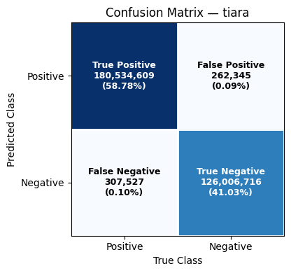

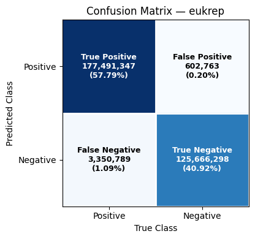

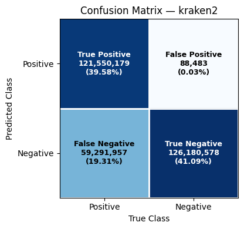

```python
def plot_confusion_from_df(metrics_df, tool_name, normalize='total'):
    """
    Confusion matrix for a single tool from bp-weighted metrics table.

    metrics_df: DataFrame with index=tool, columns [TP_bp, TN_bp, FP_bp, FN_bp]
    tool_name:  which tool (row index in the df)
    normalize:  'total' -> color by fraction of all samples
                'row'   -> color by row
                'col'   -> color by column
                None    -> raw counts for color intensity
    """
    row = metrics_df.loc[tool_name]
    TP, TN, FP, FN = row["TP"], row["TN"], row["FP"], row["FN"]

    # Arrange like schema: rows = predicted, cols = true
    M = np.array([[TP, FP],
                  [FN, TN]], dtype=float)

    # normalization for color
    C = M.copy()
    if normalize == 'total':
        tot = C.sum()
        C = C / tot if tot > 0 else C
    elif normalize == 'row':
        row_sums = C.sum(axis=1, keepdims=True)
        C = np.divide(C, row_sums, out=np.zeros_like(C), where=row_sums!=0)
    elif normalize == 'col':
        col_sums = C.sum(axis=0, keepdims=True)
        C = np.divide(C, col_sums, out=np.zeros_like(C), where=col_sums!=0)

    fig, ax = plt.subplots(figsize=(5,4))
    im = ax.imshow(C, cmap='Blues', vmin=0, vmax=C.max() if C.max()>0 else 1)

    # gridlines
    for x in (0.5, 1.5):
        ax.axvline(x, color='white', lw=2)
        ax.axhline(x, color='white', lw=2)

    # ticks
    ax.set_xticks([0,1]); ax.set_yticks([0,1])
    ax.set_xticklabels(['Positive', 'Negative'])
    ax.set_yticklabels(['Positive', 'Negative'])
    ax.set_xlabel('True Class')
    ax.set_ylabel('Predicted Class')
    ax.set_title(f'Confusion Matrix — {tool_name}')

    # annotations
    total = M.sum()
    labels = np.array([['True Positive', 'False Positive'],
                       ['False Negative', 'True Negative']])
    for i in range(2):
        for j in range(2):
            count = M[i,j]
            frac  = (count / total) if total>0 else 0
            txt = f"{labels[i,j]}\n{count:,.0f}\n({frac*100:.2f}%)"
            ax.text(j, i, txt, ha='center', va='center',
                    color='white' if C[i,j] > (C.max()*0.5) else 'black',
                    fontsize=9, fontweight='bold')

    plt.tight_layout()
    plt.show()

# Example usage
plot_confusion_from_df(metrics_bp, "tiara")
plot_confusion_from_df(metrics_bp, "eukrep")
plot_confusion_from_df(metrics_bp, "kraken2")
```

# Section #3 Binning outcomes (templates)

> **Inputs expected:** summaries exported from your binning/QC tools (e.g., CheckM, anvi'o).  
> Provide a tidy table with columns like:  
> `dataset, bin_id, completeness, contamination, total_bp`

We will:

- Count bins per quality tier (e.g., Almost complete, High-quality, Medium-quality with defined thresholds).
- Sum total bp per tier.

## Summary of all bins alongwith corresponding total bp

```python
import pandas as pd
import numpy as np

#summary.tsv is obtained from metawrap refinement results
#using a python_script "bin_stats.py"
#it considers all the refine bins and writes another column for total base pairs per bin
bins_df = pd.read_csv('summary.tsv', sep='\t')
np.random.seed(42)

bins_df['completeness'] = bins_df['completeness'].round(2)
bins_df['contamination'] = bins_df['contamination'].round(3)
print(bins_df.head())
```

```
      dataset     bin  completeness  contamination  total_bp
0  metagenome  bin.28        100.00          0.000   4440561
1  metagenome  bin.27         99.97          0.288   2568064
2  metagenome   bin.4         99.36          3.025   5054585
3  metagenome  bin.24         99.32          0.000   3052021
4  metagenome   bin.5         99.30          3.223   4803700
```

```python
pd.set_option('display.float_format', '{:.2f}'.format)
display(bins_df.head())
```

|  | dataset | bin | completeness | contamination | total_bp |
| --- | --- | --- | --- | --- | --- |
| 0 | metagenome | bin.28 | 100.00 | 0.00 | 4440561 |
| 1 | metagenome | bin.27 | 99.97 | 0.29 | 2568064 |
| 2 | metagenome | bin.4 | 99.36 | 3.02 | 5054585 |
| 3 | metagenome | bin.24 | 99.32 | 0.00 | 3052021 |
| 4 | metagenome | bin.5 | 99.30 | 3.22 | 4803700 |

```python
bins_df
```

|  | dataset | bin | completeness | contamination | total_bp |
| --- | --- | --- | --- | --- | --- |
| 0 | metagenome | bin.28 | 100.00 | 0.00 | 4440561 |
| 1 | metagenome | bin.27 | 99.97 | 0.29 | 2568064 |
| 2 | metagenome | bin.4 | 99.36 | 3.02 | 5054585 |
| 3 | metagenome | bin.24 | 99.32 | 0.00 | 3052021 |
| 4 | metagenome | bin.5 | 99.30 | 3.22 | 4803700 |
| ... | ... | ... | ... | ... | ... |
| 178 | tiara | bin.30 | 90.96 | 3.67 | 2844608 |
| 179 | tiara | bin.1 | 86.97 | 2.09 | 1998548 |
| 180 | tiara | bin.20 | 68.49 | 1.63 | 1543483 |
| 181 | tiara | bin.5 | 53.71 | 5.15 | 2663143 |
| 182 | tiara | bin.8 | 52.06 | 1.72 | 1243628 |

183 rows × 5 columns

```python
bins_df.shape[0]
```

```
183
```

## Define the quality tiers and summarize

```python
# Define your quality tiers (edit thresholds as needed)
def assign_quality_tier(row):
    cpl, cnt = row['completeness'], row['contamination']
    # Example categories (adjust to your study's definitions)
    if cpl >= 90 and cnt <= 5:
        return 'Almost Complete'
    elif cpl >= 70 and cnt <= 5:
        return 'High Quality'
    elif cpl >= 50 and cnt <= 10:
        return 'Medium Quality'
    else:
        return 'Other' # shouldn't be the case of yours, because all bins are >50% in completeness; still good to have for a sanity check

bins_df = bins_df.copy()
bins_df['quality'] = bins_df.apply(assign_quality_tier, axis=1)
summary_counts = (bins_df
                  .groupby(['dataset','quality'])
                  .size()
                  .reset_index(name='bin'))
summary_bp = (bins_df
              .groupby(['dataset','quality'])['total_bp']
              .sum()
              .reset_index(name='total_bp'))
```

```python
summary_counts
summary_counts.to_csv('bins_quality.tsv', sep='\t', index=False)
```

|  | dataset | quality | bin |
| --- | --- | --- | --- |
| 0 | bowtie2 | Almost Complete | 21 |
| 1 | bowtie2 | High Quality | 3 |
| 2 | bowtie2 | Medium Quality | 8 |
| 3 | dirty_metagenome | Almost Complete | 23 |
| 4 | dirty_metagenome | High Quality | 3 |
| 5 | dirty_metagenome | Medium Quality | 5 |
| 6 | eukrep | Almost Complete | 25 |
| 7 | eukrep | High Quality | 1 |
| 8 | eukrep | Medium Quality | 4 |
| 9 | kraken2 | Almost Complete | 24 |
| 10 | kraken2 | High Quality | 2 |
| 11 | kraken2 | Medium Quality | 4 |
| 12 | metagenome | Almost Complete | 23 |
| 13 | metagenome | High Quality | 4 |
| 14 | metagenome | Medium Quality | 3 |
| 15 | tiara | Almost Complete | 25 |
| 16 | tiara | High Quality | 1 |
| 17 | tiara | Medium Quality | 4 |

```python
summary_bp
```

|  | dataset | quality | total_bp |
| --- | --- | --- | --- |
| 0 | bowtie2 | Almost Complete | 64593960 |
| 1 | bowtie2 | High Quality | 7665773 |
| 2 | bowtie2 | Medium Quality | 22631393 |
| 3 | dirty_metagenome | Almost Complete | 71740714 |
| 4 | dirty_metagenome | High Quality | 10259514 |
| 5 | dirty_metagenome | Medium Quality | 10927740 |
| 6 | eukrep | Almost Complete | 80742064 |
| 7 | eukrep | High Quality | 1961526 |
| 8 | eukrep | Medium Quality | 9270272 |
| 9 | kraken2 | Almost Complete | 77872790 |
| 10 | kraken2 | High Quality | 4702812 |
| 11 | kraken2 | Medium Quality | 8315391 |
| 12 | metagenome | Almost Complete | 75135859 |
| 13 | metagenome | High Quality | 12925070 |
| 14 | metagenome | Medium Quality | 6156989 |
| 15 | tiara | Almost Complete | 80871674 |
| 16 | tiara | High Quality | 1998548 |
| 17 | tiara | Medium Quality | 10178039 |